```python
import numpy as np
import pandas as pd
import matplotlib.pyplot as plt
```

# Практическая работа 6. Визуализация данных

```
Цель работы: необходимо использовать датасет с прошлой практической работы и визуализировать данные в виде графиков. Нужно было использовать: линейный график - минимум 3 штуки (можно использовать наложение графиков), столбчатая диаграмма- минимум 3 штуки(можно также использовать наложение), круговая диаграмма - минимум 2 штуки, диаграмма рассеяния - минимум 2 штуки, гистограмма - минимум 3 штуки. Для каждого графика необходимо оформить подробное описание, а так же нужно описать, что изображено на графике, как это получилось, какие выводы были сделаны исходя из полученных данных.
```

В блоке кода сверху мы испортирует библиотеки numpy, pandas и matplotlib.

```python
terraria = pd.read_csv('terraria.csv')
terraria
```

|  | NAME | CLASS | GAME PROGRESSION | DPS (SINGLE TARGET) | DPS (MULTI TARGET) | DPS (SINGLE TARGET + PROYECTILE ONLY) | DPS (MULTI TARGET + PROYECTILE ONLY) | OBSERVATIONS |
| --- | --- | --- | --- | --- | --- | --- | --- | --- |
| 0 | Zenith | Melee | Post-Moonlord | 4800 | 13000.0 | NaN | NaN | NaN |
| 1 | Last Prism | Mage | Post-Moonlord | 3657 | 1142.0 | NaN | NaN | Fully charged |
| 2 | Star Wrath | Melee | Post-Moonlord | 2700 | 5800.0 | 1500.0 | 3700.0 | NaN |
| 3 | Terrarian | Melee | Post-Moonlord | 2200 | 4600.0 | 700.0 | 1000.0 | NaN |
| 4 | Meowmere | Melee | Post-Moonlord | 2100 | 6400.0 | 1300.0 | 3400.0 | NaN |
| ... | ... | ... | ... | ... | ... | ... | ... | ... |
| 390 | Paper Plane | Ranger | Pre-Boss | 14 | NaN | NaN | NaN | Does not pierce |
| 391 | Finch Staff | Summoner | Pre-Boss | 10 | 25.0 | NaN | NaN | NaN |
| 392 | Flameburst Rod | Summoner | Pre-Boss | 8 | 18.0 | NaN | NaN | Only two dummies |
| 393 | Flinx Staff | Summoner | Pre-Boss | 8 | 70.0 | NaN | NaN | NaN |
| 394 | Lightning Aura Rod | Summoner | Pre-Boss | 8 | 24.0 | NaN | NaN | NaN |

395 rows × 8 columns

Читаем наш файл с оружиями из игры Terraria, записываем в переменную и выводим в виде таблицы.

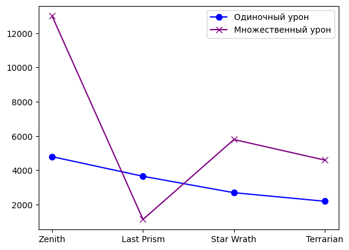

```python
# NAME,CLASS,GAME PROGRESSION,DPS (SINGLE TARGET),DPS (MULTI TARGET),DPS (SINGLE TARGET + PROYECTILE ONLY),DPS (MULTI TARGET + PROYECTILE ONLY),OBSERVATIONS

plt.plot(terraria['NAME'].head(4), terraria['DPS (SINGLE TARGET)'].head(4), marker = 'o', markersize = 7, label = 'Одиночный урон', color = 'blue')
plt.plot(terraria['NAME'].head(4), terraria['DPS (MULTI TARGET)'].head(4), marker = 'x', markersize = 7, label = 'Множественный урон', color = 'purple')
plt.legend()
plt.show()
```

Линейный график соотношения одиночного и множественного урона у 4 самых мощных оружий в террарии, с помощью него мы можем наблюдать что у Последней призмы множественный урон меньше, а одиночный высок, а у меча Зенит всё наоборот. plt.plot создает график, plt.legend показывает легенду а plt.show выводит нам график.

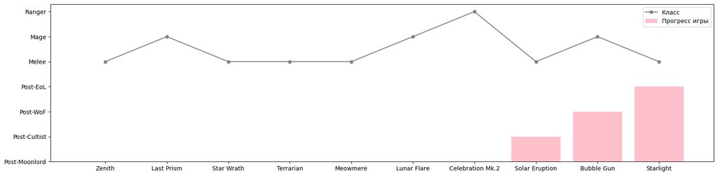

```python
plt.figure().set_figwidth(20)
plt.bar(terraria['NAME'].head(10), terraria['GAME PROGRESSION'].head(10), label = "Прогресс игры", color = 'pink')
plt.plot(terraria['NAME'].head(10), terraria['CLASS'].head(10), marker = "o", markersize = 5, label = 'Класс', color = 'grey' )
plt.legend()
plt.show()
```

В первой строке мы расширяем наше полотно, линией мы смотрим оружие какого класса перед нами, стобцами какой стадии прохождения оружия и видим что больше всего оружий после Лунного Лорда являются оружиями ближнего боя.

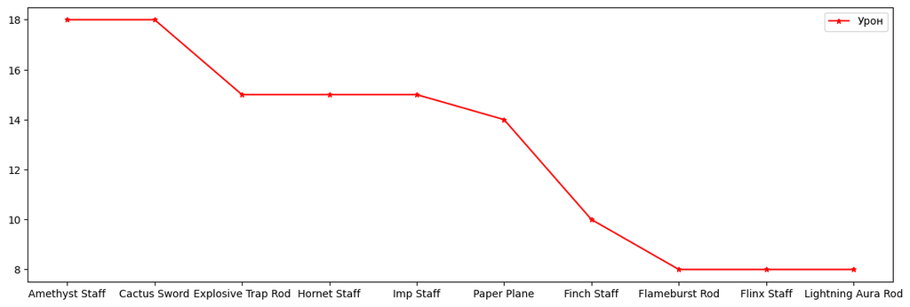

```python
plt.figure().set_figwidth(15)
plt.plot(terraria['NAME'].tail(10),terraria['DPS (SINGLE TARGET)'].tail(10), marker = '*', markersize = 5, label = 'Урон', color = 'red')
plt.legend()
plt.show()
```

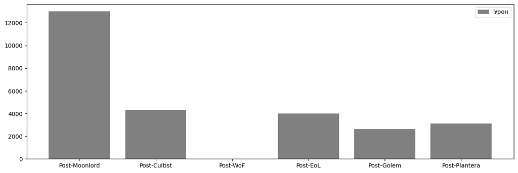

```python
plt.figure().set_figwidth(15)
plt.bar(terraria['GAME PROGRESSION'].head(20),terraria['DPS (MULTI TARGET)'].head(20), label = 'Урон', color = 'grey')
plt.legend()
plt.show()
```

Здесь продемонстрирована столбчатая диаграмма соотношения урона оружия по множественной цели, касательно прогресса в игре. Снизу прогресс, слева урон, справа сверху легенда.

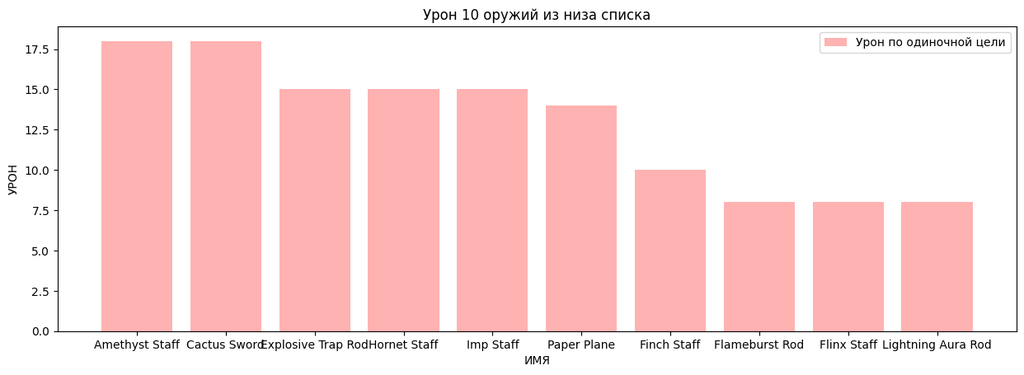

```python
plt.figure().set_figwidth(15)
plt.bar(terraria['NAME'].tail(10), terraria['DPS (SINGLE TARGET)'].tail(10), label = "Урон по одиночной цели", color = 'red', alpha = 0.3)
plt.ylabel("УРОН")
plt.xlabel("ИМЯ")
plt.title("Урон 10 оружий из низа списка")
plt.legend()
plt.show()
```